# Exploring ASER2016 Pakistan Data

Yusei Hara

2020/10/1

## ASER Pakistan 2016

In this piece of paper, a set of data obtained from Annual Status of Education Report (ASER) is explored. The raw data was downloaded from the link here. https://palnetwork.org/aser-centre/

### Preparation

#### Packages Used

```r
library(tidyverse)
library(ggplot2)
library(ggthemes)
library(ggrepel)
library(gghighlight)
library(stringr)
library(dplyr)
library(sf)
library(scatterplot3d)
library(car)
# library(broom)
require(ggiraph)
require(ggiraphExtra)

# require(plyr)
```

#### Data Installation

```r
provdist <- read.csv("aser/ASER2016ProvDist.csv")
school <- read.csv("aser/ASER2016GSchool.csv")
child <- read.csv("aser/ASER2016Child.csv")
pschool <- read.csv("aser/ASER2016PvtSchool.csv")
gschool <- read.csv("aser/ASER2016GSchool.csv")
parent <- read.csv("aser/ASER2016Parent.csv")
house <- read.csv("aser/ASER2016HouseholdIndicators.csv")
```

```r
RegionName <- c("2" = "Panjab",
                "3" = "Sindh",
                "4" = "Balochistan",
                "5" = "Khyber Pakhtunkhwa",
                "6" = "Gilgit-Baltistan",
                "7" = "Azad Jammu and Kashmir",
                "8" = "Islamabad - ICT",
                "9" = "Federally Administrated Tribal Areas")
Gender <- c("0" = "Male",
            "-1" = "Female")
```

### Exploration

#### Checking Samplesizes

```r
length(unique(child$CID))
```

```
## [1] 255196
```

The whole samplesize (the numebr of children) of this dataset is 255196.

```r
child %>%
  filter(DID == 266) %>%
  summarize(N_hunza = length(unique(CID)))
```

| N_hunza |
| --- |
| 1641 |

The samplesize of Hunza alone is 1641.

### Exploration in Hunza

#### Gender Proportion

```r
child %>%
  filter(DID == 266) %>%
  summarize(gender_proportion = mean(C002))
```

| gender_proportion |
| --- |
| -0.5173675 |

-1: female, 0: male  
gender_proportion = -0.5173675 means there are a little more girls in the dataset.

#### Age of Children (C001)

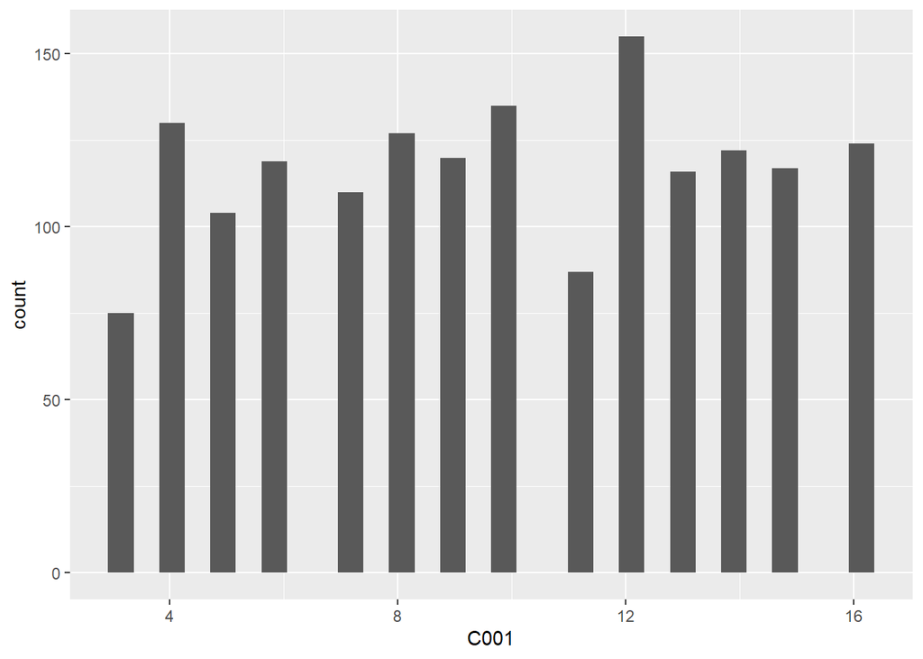

```r
child %>%
  filter(DID == 266) %>%
  ggplot(aes(C001)) +
  geom_histogram()
```

Age is well sparsed

#### Eduation Status

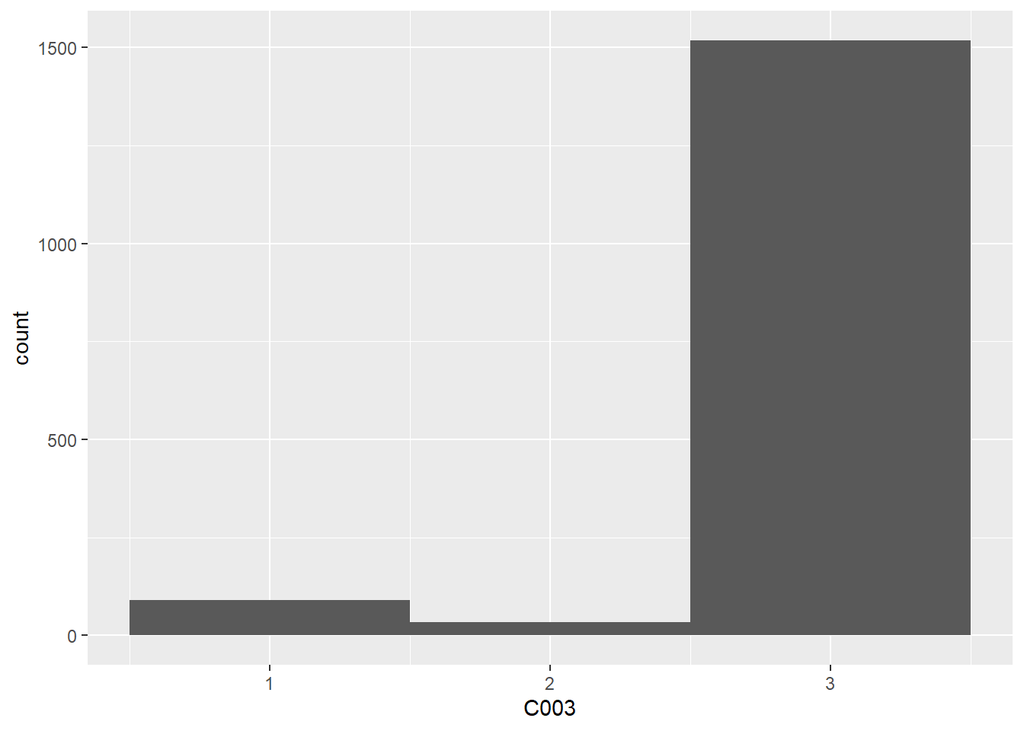

```r
child %>%
  filter(DID == 266) %>%
  ggplot(aes(C003)) +
  geom_histogram(bins = 3)
```

1 = never enrolled; 2 = drop-out; 3 = currently enrolled

#### Education Status by Gender

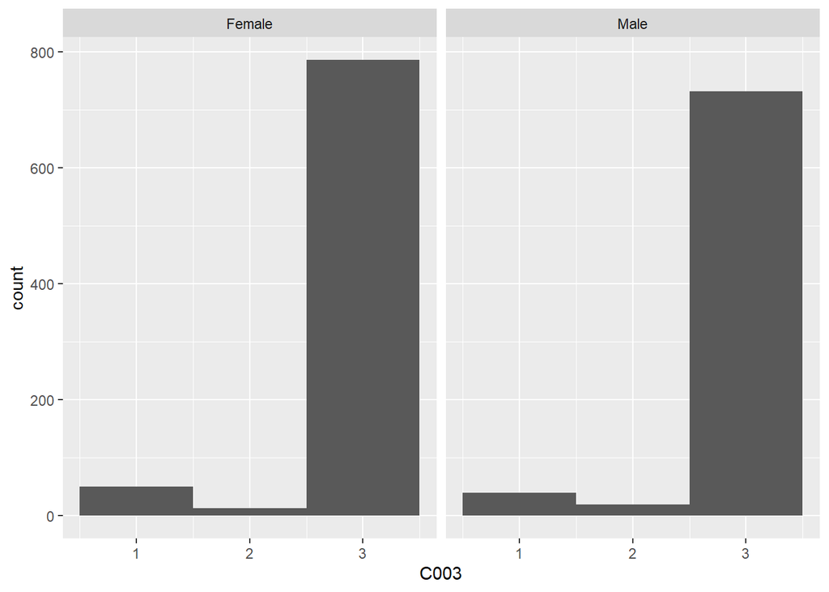

```r
child %>%
  filter(DID == 266) %>%
  ggplot(aes(C003)) +
  geom_histogram(bins = 3, binwidth = 1) +
  facet_grid(~C002, labeller = labeller(C002 = Gender))
```

Both genders look pretty good interms of the absolute number of currently-enrolled-children

#### The Enrollment Rate by Gender

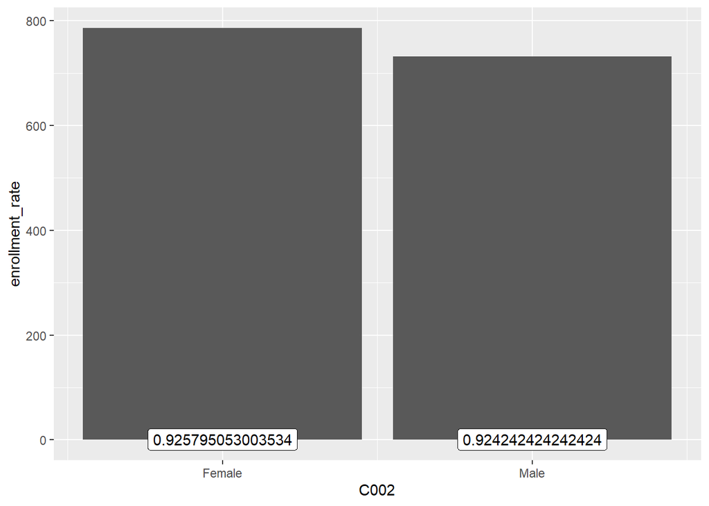

```r
child %>%
  filter(DID == 266) %>%
  group_by(C002) %>%
  mutate(enrollment_rate = mean(C003 == 3)) %>%
  ggplot(aes(C002, enrollment_rate)) +
  geom_col() +
  scale_y_continuous() +
  geom_label(aes(label = enrollment_rate)) +
  scale_x_continuous(breaks = c(-1, 0), labels = c("Female", "Male"))
```

As a rate, both are doing pretty good

#### Currently-Enrolled: Institution Type (C006)

1 = Government; 2 = Private; 3 = Madrasah(Conventional religious education) School; 4 = Other(Non formal education facility)

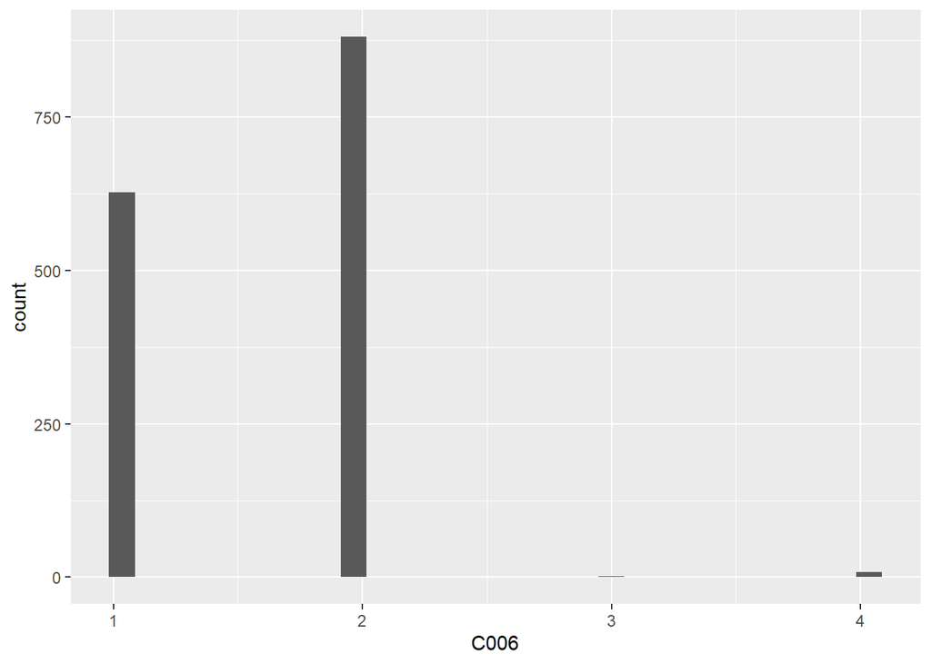

```r
child %>%
  filter(DID == 266) %>%
  ggplot(aes(C006)) +
  geom_histogram()
```

Most children go to public schools or private schools

#### Within Gilgit-Baltistan

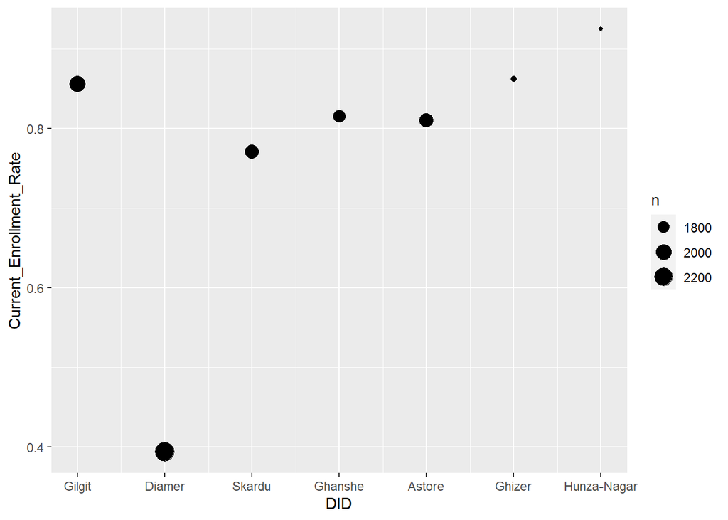

```r
child %>%
  filter(RID == 6) %>%
  group_by(DID) %>%
  mutate(Current_Enrollment_Rate = mean(C003 == 3)) %>%
  ggplot(aes(DID, Current_Enrollment_Rate)) +
  geom_count() +
  scale_x_continuous(breaks = 260:266, labels = c("Gilgit", "Diamer", "Skardu", "Ghanshe", "Astore", "Ghizer", "Hunza-Nagar"))
```

Within Gilgit-Baltistan, Hunza is outperforming.

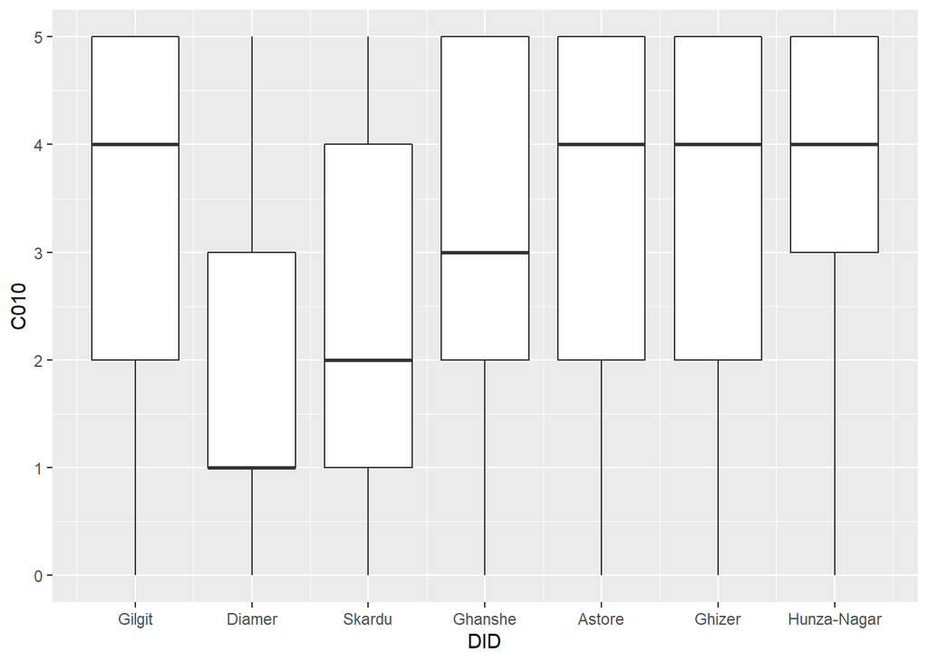

```r
child %>%
  filter(RID == 6) %>%
  group_by(DID) %>%
  ggplot(aes(DID, C010)) +
  geom_boxplot(aes(group = DID)) +
  scale_x_continuous(breaks = 260:266, labels = c("Gilgit", "Diamer", "Skardu", "Ghanshe", "Astore", "Ghizer", "Hunza-Nagar"))
```

#### Basic Learning Levels: Reading in Local/National Language (C010)

1 = Begginer/Nothing; 2 = Letters; 3 = Words; 4 = Sentences; 5 = Story

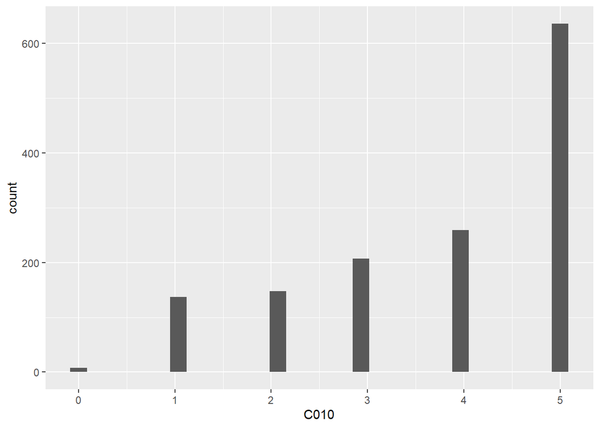

```r
child %>%
  filter(DID == 266) %>%
  ggplot(aes(C010)) +
  geom_histogram()
```

```r
child %>%
  filter(DID == 266) %>%
  summarize(na = sum(is.na(C010)))
```

| na |
| --- |
| 246 |

#### Basic Learning Levels by Age

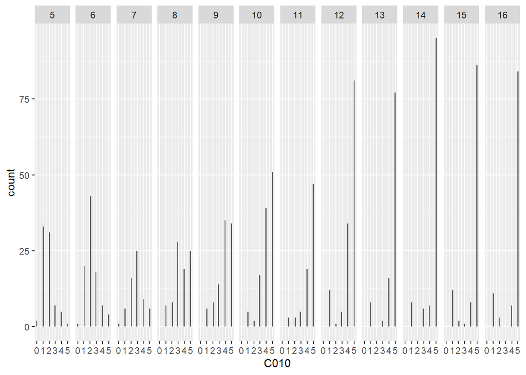

```r
child %>%
  filter(DID == 266, C013 != c(3,4)) %>%
  ggplot(aes(C010)) +
  geom_histogram() +
  facet_grid(~C001)
```

```r
# children at he age of 3 and 4 are removed for they have not data
```

#### Basic Learning Levels by Gender

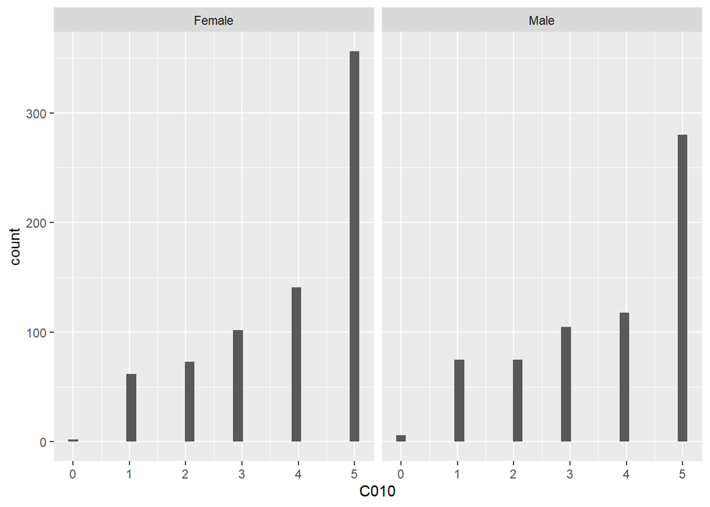

```r
child %>%
  filter(DID == 266) %>%
  ggplot(aes(C010)) +
  geom_histogram() +
  facet_grid(~C002, labeller = labeller(C002 = Gender))
```

#### English Reading Levels (C013)

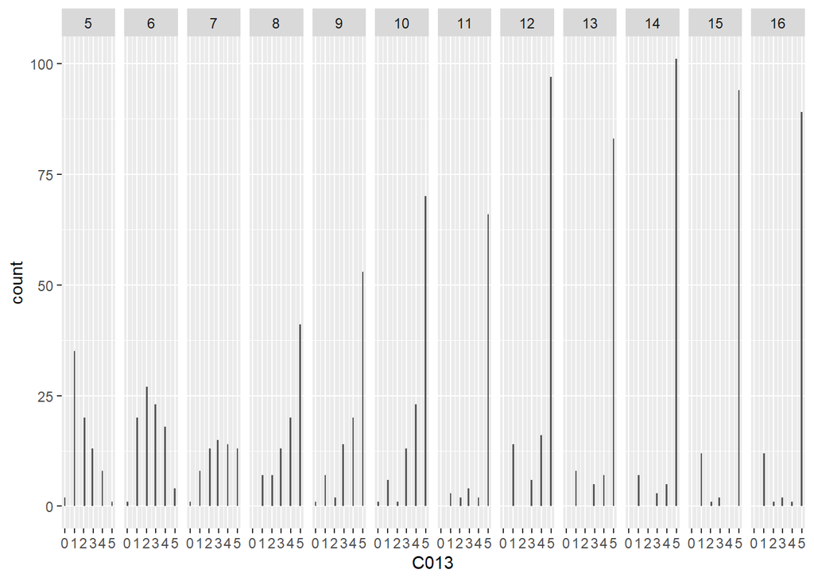

```r
child %>%
  filter(DID == 266, C013 != c(3,4)) %>%
  ggplot(aes(C013)) +
  geom_histogram() +
  facet_grid(~C001)
```

```r
# children at he age of 3 and 4 are removed for they have not data
```

#### English Reading Levels by Gender

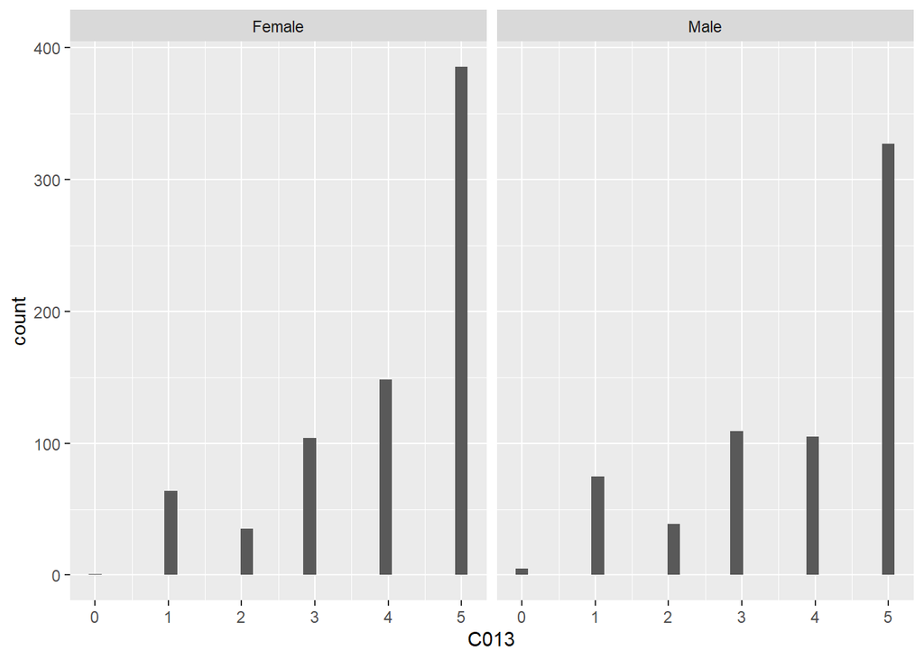

```r
child %>%
  filter(DID == 266) %>%
  ggplot(aes(C013)) +
  geom_histogram() +
  facet_grid(~C002, labeller = labeller(C002 = Gender))
```

```r
child %>%
  filter(DID == 266) %>%
  group_by(C002) %>%
  summarize(enrollment_rate = mean(C003 == 3, na.rm = TRUE))
```

| C002 | enrollment_rate |
| --- | --- |
| -1 | 0.9257951 |
| 0 | 0.9242424 |

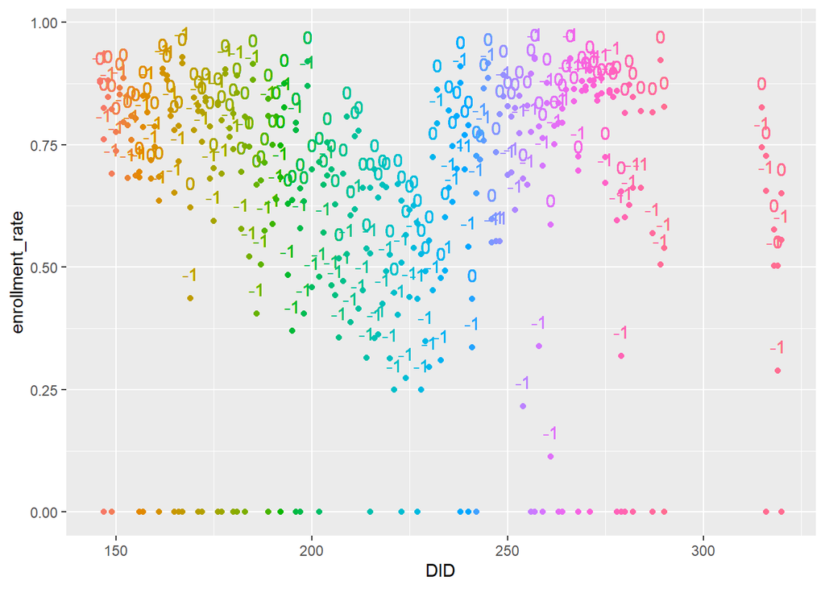

```r
child %>%
  group_by(DID, C002) %>%
  mutate(enrollment_rate = mean(C003 == 3, na.rm = TRUE)) %>%
  ggplot(aes(DID, enrollment_rate, color = factor(DID), label = C002)) +
  geom_point(show.legend = FALSE) +
  geom_text(aes(label = C002), show.legend = FALSE, nudge_y = 0.05)
```

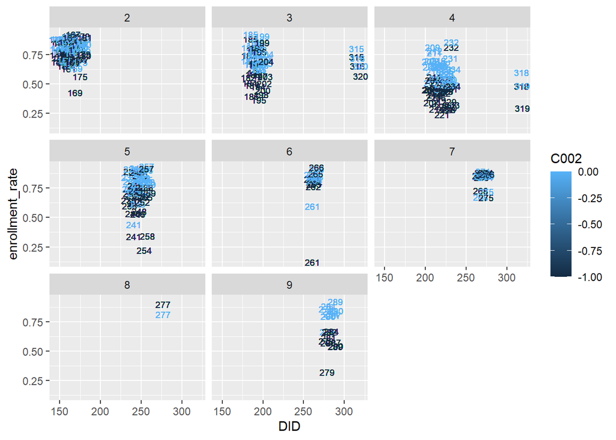

```r
child %>%
  filter(C002 == c(0, -1)) %>%
  group_by(DID, C002) %>%
  mutate(enrollment_rate = mean(C003 == 3, na.rm = TRUE)) %>%
  ggplot(aes(DID, enrollment_rate, color = C002, label = DID)) +
  geom_text(aes(label = DID), size = 2.5) +
  facet_grid(.~RID) +
  facet_wrap(.~RID)
```

### Comparison between Other Region

#### Current Enrollment Rate

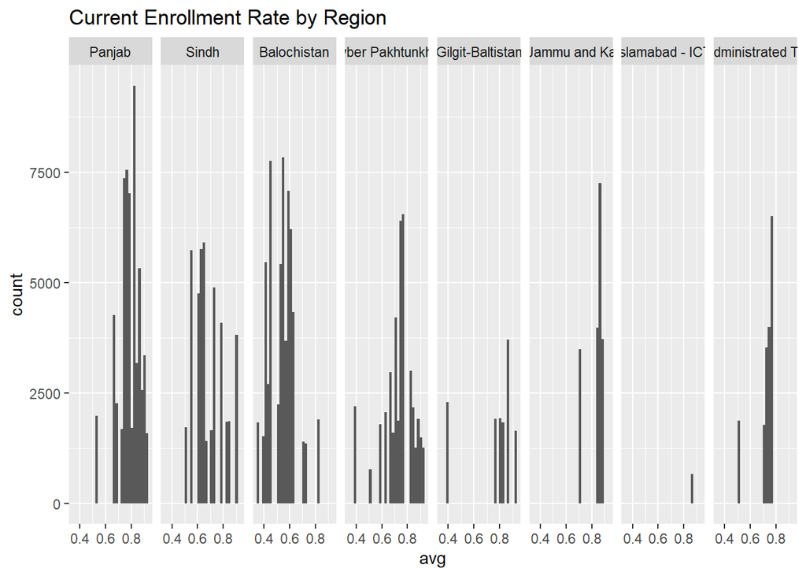

```r
child %>%
  group_by(DID) %>%
  mutate(avg = round(mean(C003 == 3), digits = 2)) %>%
  ungroup() %>%
  ggplot(aes(avg)) +
  geom_histogram() +
  facet_grid(~RID, labeller = labeller(RID = RegionName)) +
  labs(title = "Current Enrollment Rate by Region")
```

#### Female Average Learning Levels (Age or other variables are NOT adjusted)

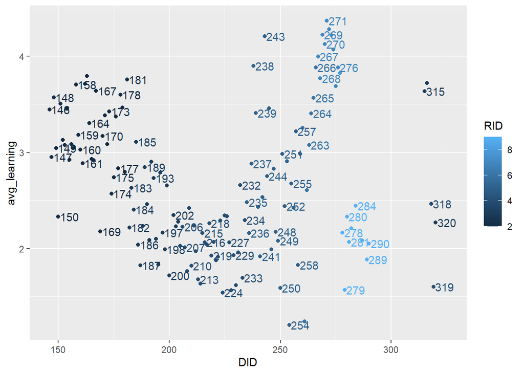

```r
child %>%
  filter(C002 == -1) %>%
  group_by(DID) %>%
  mutate(avg_learning = mean(C010, na.rm = TRUE)) %>%
  ggplot(aes(DID, avg_learning, color = RID)) +
  geom_point() +
  geom_text(aes(label = DID), nudge_x = 5, check_overlap = TRUE)
```

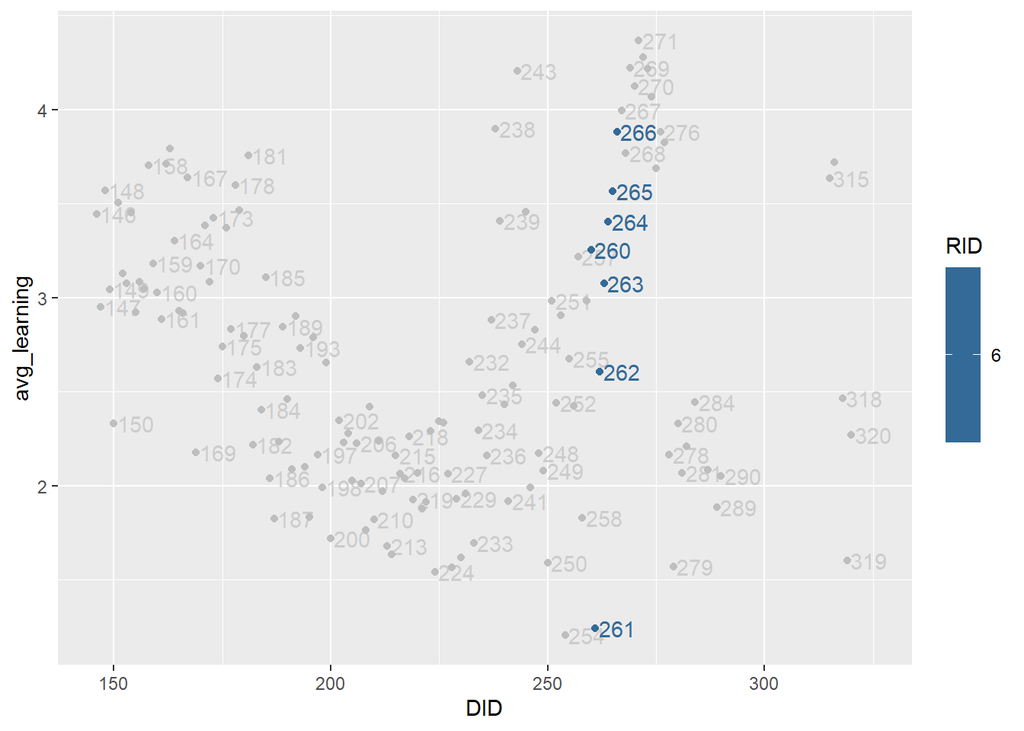

```r
child %>%
  filter(C002 == -1) %>%
  group_by(DID) %>%
  mutate(avg_learning = mean(C010, na.rm = TRUE)) %>%
  ggplot(aes(DID, avg_learning, color = RID)) +
  geom_point() +
  geom_text(aes(label = DID), nudge_x = 5, check_overlap = TRUE) +
  gghighlight(RID == 6)
```

It is interesting to note that Gilgit-Baltistan(RID==6) has a huge diversity in average learning levels of girls and Hunza(DID==266) is in the top group of all region.

### Spatial Analysis

#### Districts Map

```r
ica_df <- ica %>%
  mutate(centroid = st_centroid(geometry),
    x = st_coordinates(centroid)[,1],
    y = st_coordinates(centroid)[,2]) %>%
  as.data.frame()
ica_df <- ica_df %>% select(Province, Districts, x, y)
ica_df <- ica_df %>% summarize(Province = tolower(Province), Districts = tolower(Districts), x = x, y = y)
```

#### Child and ProvDist data combination

```r
child_dname <- child %>% left_join(provdist[-1])
child_dname <- child_dname %>% mutate(dname = tolower(DNAME))
```

```r
ica_df_3 <- ica_df %>% filter(Province == "sindh")

ica_df_3$Districts <- ica_df_3$Districts %>%
  str_replace("ghotki", "gotki") %>%
  str_replace("mirpur khas", "mirpurkhas") %>%
  str_replace("malir karachi", "karachi-malir-rural") %>%
  str_replace("naushahro feroze", "nowshero feroze") %>%
  str_replace("kambar shahdad kot", "qambar shahdadkot") %>%
  str_replace("sujawal", "sajawal") %>%
  str_replace("shaheed benazir abad", "shaheed benazirabad") %>%
  str_replace("tando allahyar", "tando allah yar") %>%
  as.vector()

child_dname_3 <- child_dname %>% filter(RNAME == "Sindh") %>% left_join(ica_df_3, by = c("dname" = "Districts"))

child_dname_3 %>% group_by(dname) %>% summarize(n = sum(x))
```

| dname | n |
| --- | --- |
| badin | 132177.00 |
| dadu | 130943.92 |
| gotki | 138955.01 |
| hyderabad | 126370.38 |
| jacobabad | 113124.08 |
| jamshoro | 95519.55 |
| karachi-malir-rural | 75832.37 |
| karachi-west-rural | NA |
| kashmore | 132645.93 |
| khairpur | 107834.47 |

[output cut: 15 more lines]

```r
ica_df_3
```

| Province | Districts | x | y |
| --- | --- | --- | --- |
| sindh | badin | 68.84219 | 24.72277 |
| sindh | central karachi | 67.05813 | 24.94777 |
| sindh | dadu | 67.49687 | 26.86763 |
| sindh | east karachi | 67.13429 | 24.93583 |
| sindh | gotki | 69.65163 | 27.82827 |
| sindh | hyderabad | 68.45633 | 25.34110 |
| sindh | jacobabad | 68.47705 | 28.20721 |
| sindh | jamshoro | 67.79244 | 25.73650 |
| sindh | qambar shahdadkot | 67.71121 | 27.63562 |
| sindh | kashmore | 69.23065 | 28.27468 |

[output cut: 19 more lines]

#### District IDs

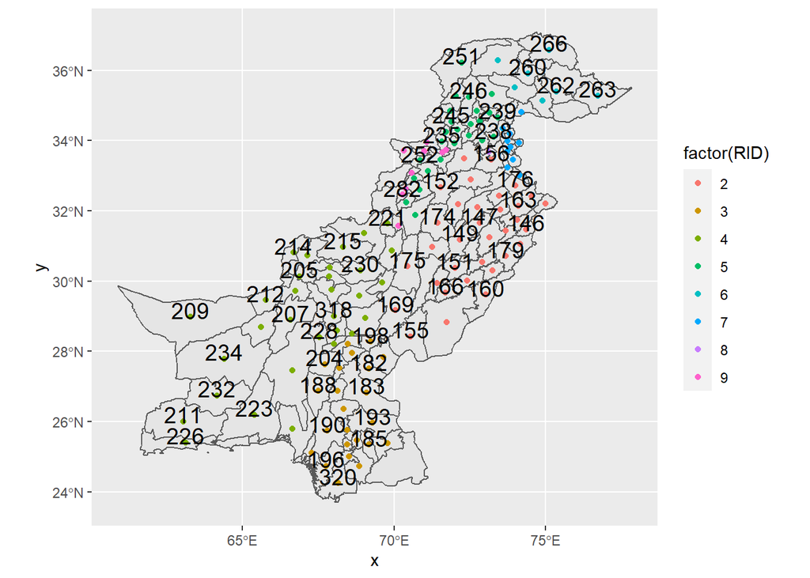

```r
ica %>%
  mutate(centroid = st_centroid(geometry),
    x = st_coordinates(centroid)[,1],
    y = st_coordinates(centroid)[,2]) %>%
    ggplot() +
  geom_sf() +
  geom_point(data = child_ica, aes(x, y, label = DID, color = factor(RID))) +
  geom_text(data = child_ica, aes(x, y, label = DID), size = 5, nudge_y = 0.2, check_overlap = TRUE)
```

#### Gilgit-Baltistan Region

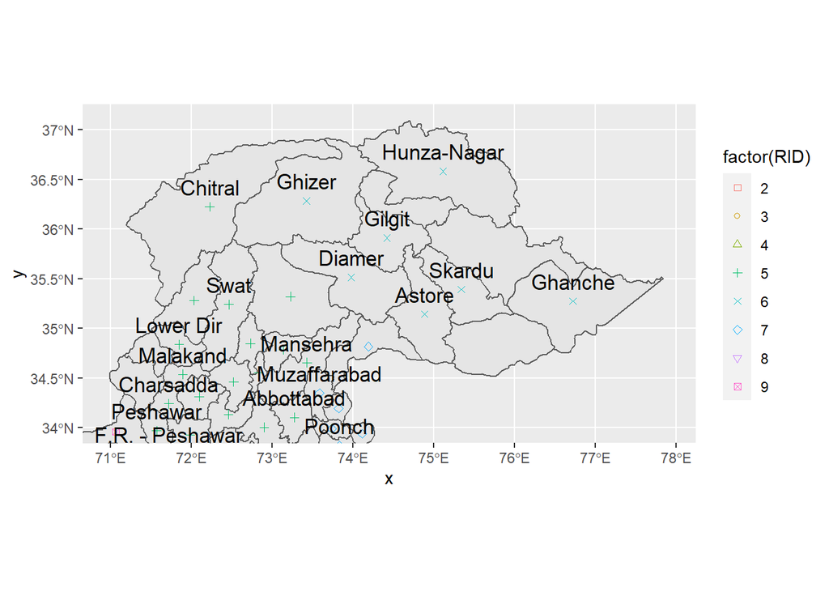

```r
ica %>%
  mutate(centroid = st_centroid(geometry),
    x = st_coordinates(centroid)[,1],
    y = st_coordinates(centroid)[,2]) %>%
    ggplot() +
  geom_sf() +
  geom_point(data = child_ica, aes(x, y, label = DNAME, shape = factor(RID), color = factor(RID))) +
  geom_text(data = child_ica, aes(x, y, label = DNAME), size = 4.5, nudge_y = 0.2, check_overlap = TRUE) +
  scale_shape_manual(values = 0:8) +
  coord_sf(xlim = c(71, 77.9), ylim = c(34, 37.1))
```

#### Latitudes and longitudes of Gilgit-Baltistan region

```r
child_ica %>%
  filter(RID == 6) %>%
  summarise(xmin = min(x), xmax = max(x), ymin = min(y), ymax = max(y))
```

| xmin | xmax | ymin | ymax |
| --- | --- | --- | --- |
| 73.42528 | 76.72102 | 35.14505 | 36.58158 |

#### Average enrollment rate

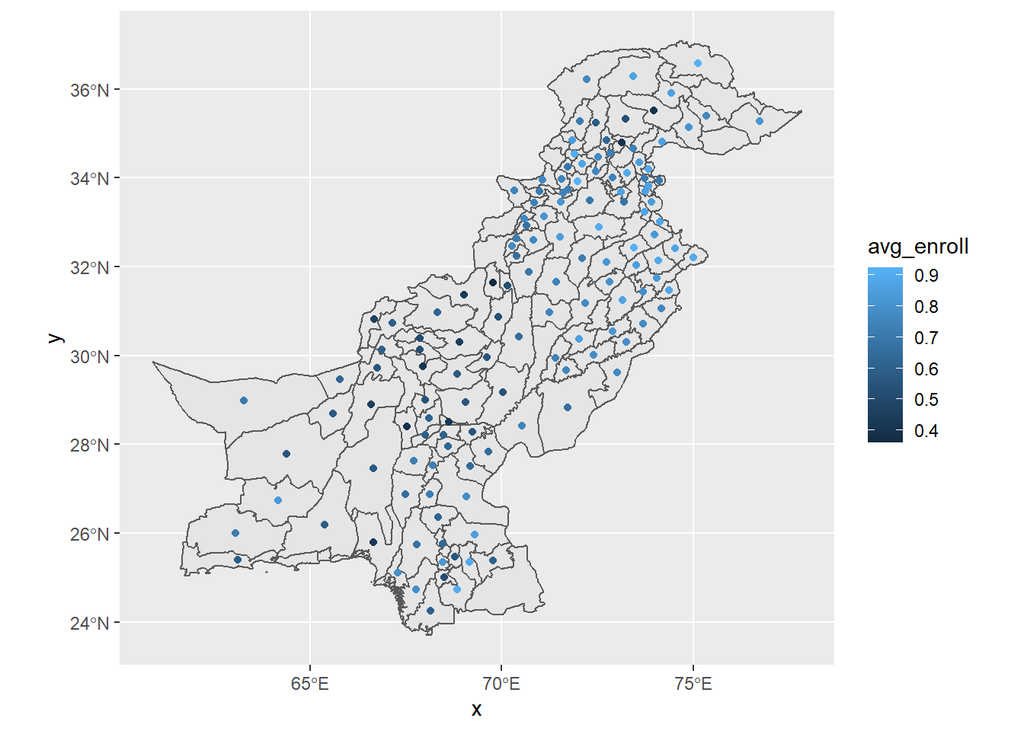

```r
ica %>%
  mutate(centroid = st_centroid(geometry),
    x = st_coordinates(centroid)[,1],
    y = st_coordinates(centroid)[,2]) %>%
    ggplot() +
  geom_sf() +
  geom_point(data = child_ica %>% group_by(DID) %>%
               mutate(avg_enroll = mean(C003 == 3)),
             aes(x, y, label = avg_enroll, color = avg_enroll))
```

```r
  # geom_text(data = child_ica%>% group_by(DID) %>%
  #             mutate(avg_enroll = mean(C003 == 3)),
  #           aes(x, y, avg_enroll), check_overlap = TRUE, nudge_y = 0.5)
```

#### Average enrollment rate of female children

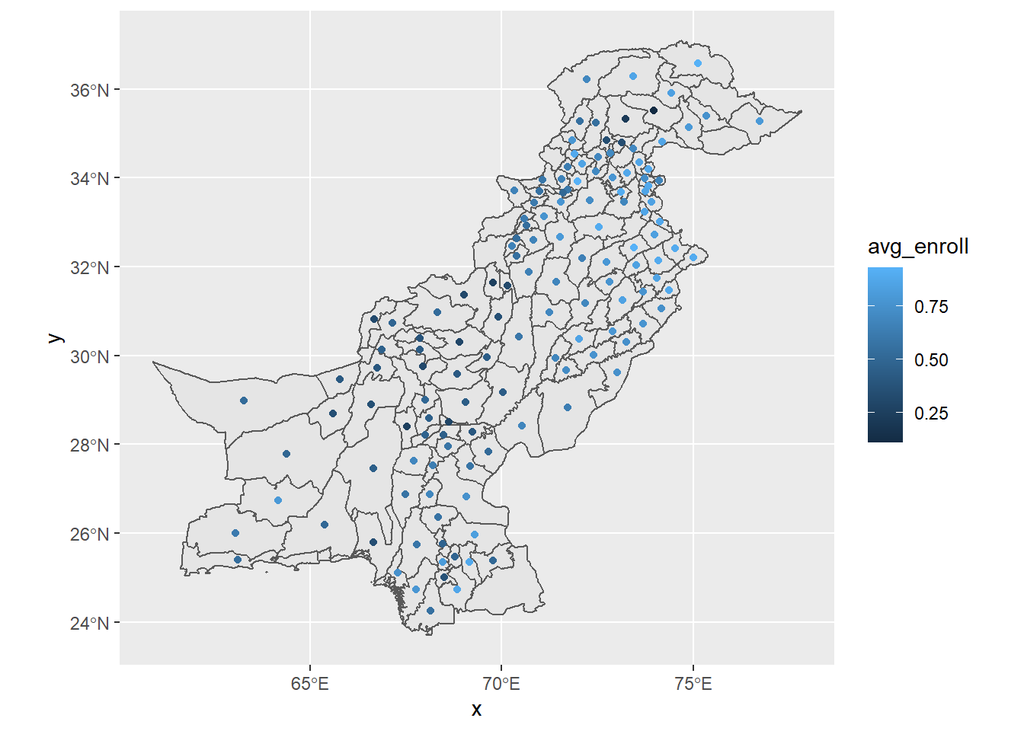

```r
ica %>%
  mutate(centroid = st_centroid(geometry),
    x = st_coordinates(centroid)[,1],
    y = st_coordinates(centroid)[,2]) %>%
    ggplot() +
  geom_sf() +
  geom_point(data = child_ica %>% filter(C002 == -1) %>% group_by(DID) %>%
               mutate(avg_enroll = mean(C003 == 3)),
             aes(x, y, label = avg_enroll, color = avg_enroll))
```

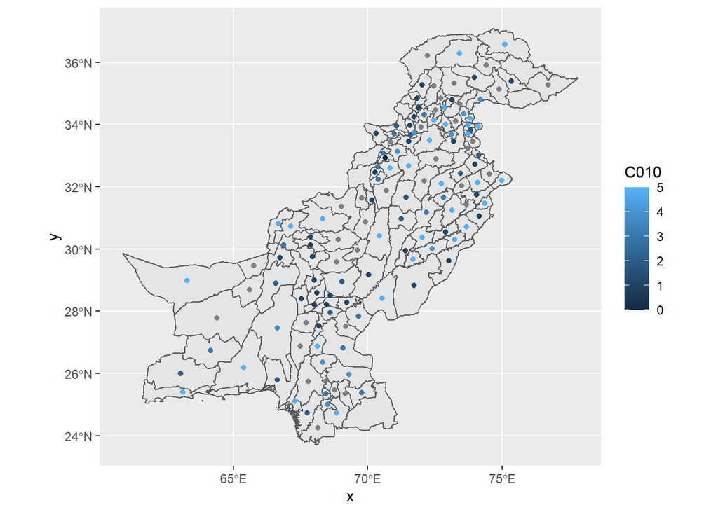

```r
ica %>%
  mutate(centroid = st_centroid(geometry),
    x = st_coordinates(centroid)[,1],
    y = st_coordinates(centroid)[,2]) %>%
    ggplot() +
  geom_sf() +
  geom_point(data = child_ica, aes(x, y, label = C010, color = C010))
```

```r
  # geom_text(data = child_ica, aes(x, y, label = C010), check_overlap = TRUE, nudge_y = 1)
```

#### Traial: children, gender

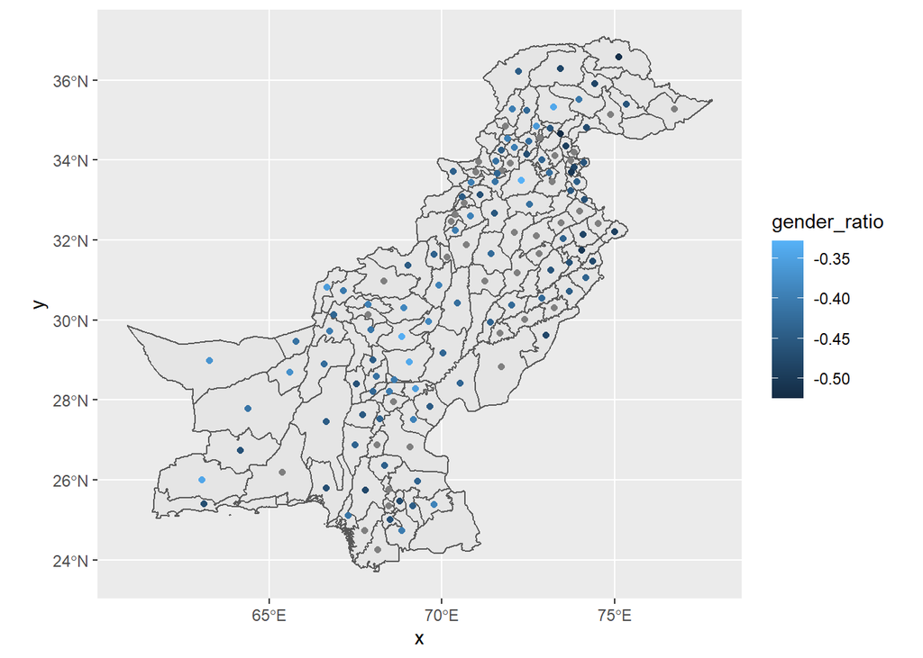

```r
ica %>%
  mutate(centroid = st_centroid(geometry),
    x = st_coordinates(centroid)[,1],
    y = st_coordinates(centroid)[,2]) %>%
    ggplot() +
  geom_sf() +
  geom_point(data = child_ica %>%
               group_by(DID) %>%
               mutate(gender_ratio = mean(C002)),
             aes(x, y, label = gender_ratio, color = gender_ratio))
```

0: male, -1: female

Thus, -0.5 indicates the complete gender parity

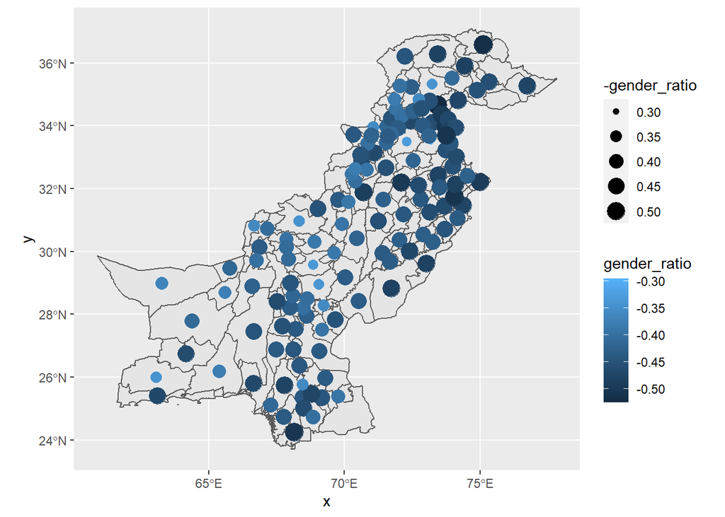

```r
ica %>%
  mutate(centroid = st_centroid(geometry),
    x = st_coordinates(centroid)[,1],
    y = st_coordinates(centroid)[,2]) %>%
    ggplot() +
  geom_sf() +
  geom_point(data = child_ica %>% group_by(DID) %>%
  mutate(gender_ratio = mean(C002, na.rm = TRUE)), aes(x, y, label = gender_ratio, color = gender_ratio, size = -gender_ratio))
```

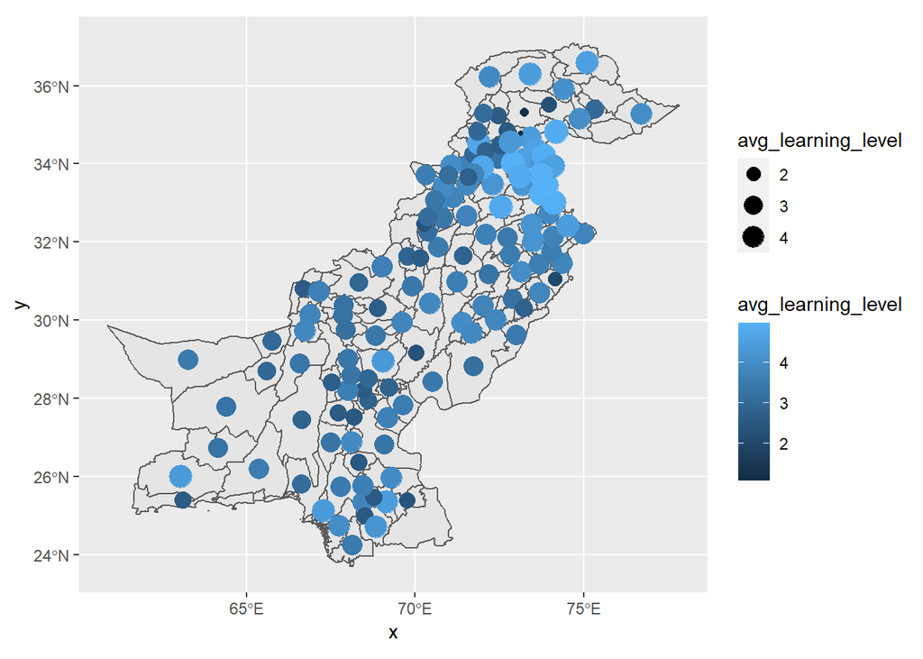

```r
ica %>%
  mutate(centroid = st_centroid(geometry),
    x = st_coordinates(centroid)[,1],
    y = st_coordinates(centroid)[,2]) %>%
    ggplot() +
  geom_sf() +
  geom_point(data = (child_ica %>% filter(C001 == 14:16) %>% group_by(DID) %>%
               mutate(avg_learning_level = mean(C010, na.rm = TRUE))), aes(x, y, label = avg_learning_level, color = avg_learning_level, size = avg_learning_level))
```

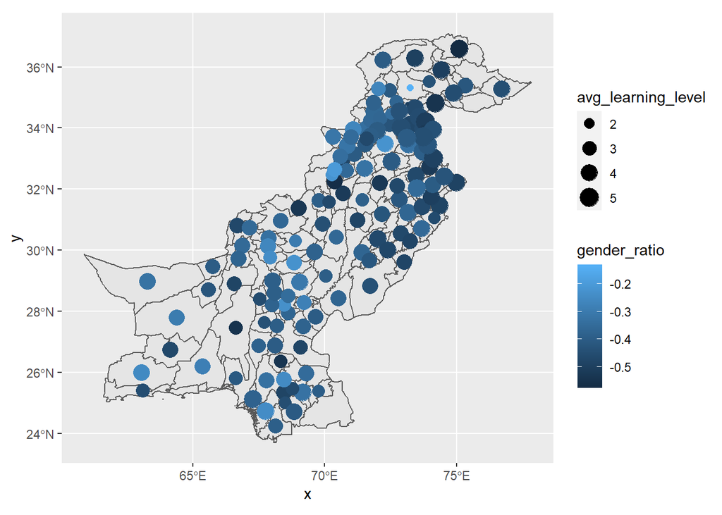

```r
ica %>%
  mutate(centroid = st_centroid(geometry),
    x = st_coordinates(centroid)[,1],
    y = st_coordinates(centroid)[,2]) %>%
    ggplot() +
  geom_sf() +
  geom_point(data = (child_ica %>% filter(C001 == 12:16) %>% group_by(DID) %>%
                       mutate(gender_ratio = mean(C002, na.rm = TRUE), avg_learning_level = mean(C010, na.rm = TRUE))), aes(x, y, label = gender_ratio, color = gender_ratio, size = avg_learning_level)) +
  theme(axis.title = element_text())
```

#### Average Local/National Language Level Across Ages by Rgion

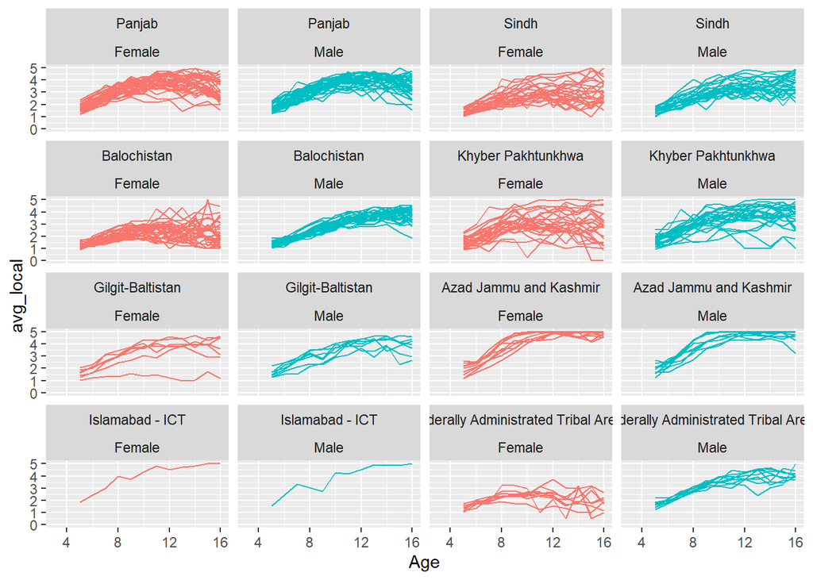

```r
child_ica %>%
  filter(C002 == c(0,-1)) %>%
  group_by(DID, C001, C002) %>%
  mutate(avg_local = mean(C010, na.rm = TRUE)) %>%
  ggplot(aes(C001, avg_local, color = factor(C002), group = DID)) +
  geom_line(show.legend = FALSE) +
  labs(x = "Age") +
  facet_grid(RID~C002, labeller = labeller(RID = RegionName, C002 = Gender)) +
  facet_wrap(RID~C002, labeller = labeller(RID = RegionName, C002 = Gender))
```

#### Average Enrollment Rate Across Ages by Rgion

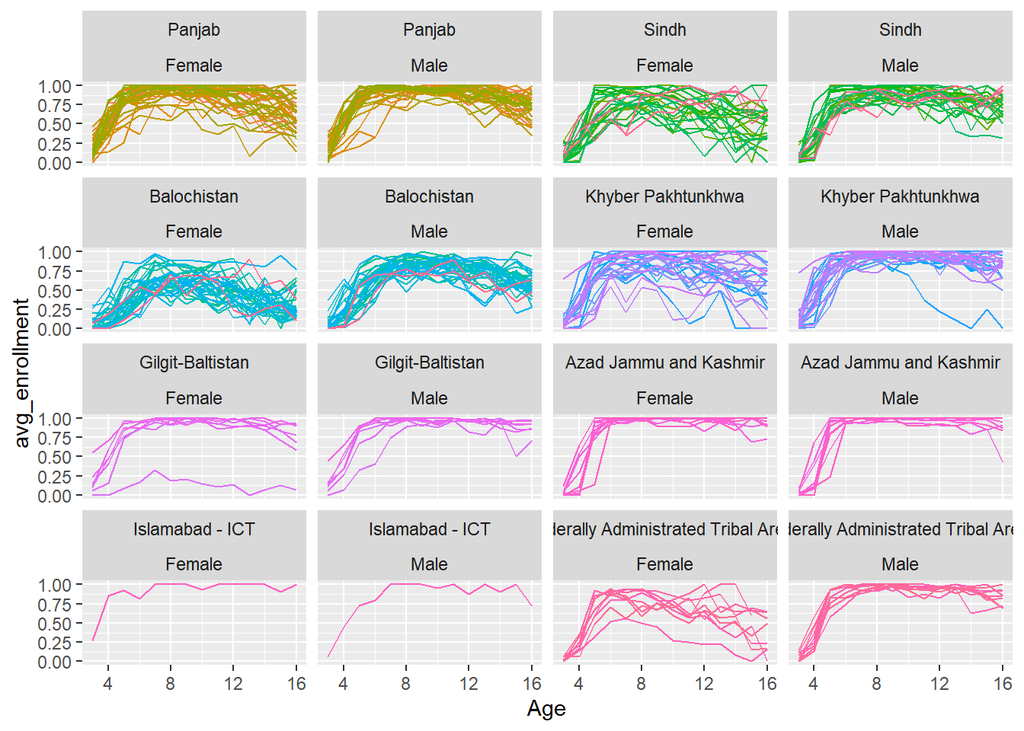

```r
child_ica %>%
  filter(C002 == c(0,-1)) %>%
  group_by(DID, C001, C002) %>%
  mutate(avg_enrollment = mean(C003 == 3, na.rm = TRUE)) %>%
  ggplot(aes(C001, avg_enrollment, color = factor(DID), group = DID)) +
  geom_line(show.legend = FALSE) +
  labs(x = "Age") +
  facet_grid(RID~C002, labeller = labeller(RID = RegionName, C002 = Gender)) +
  facet_wrap(RID~C002, labeller = labeller(RID = RegionName, C002 = Gender))
```

#### Hunza

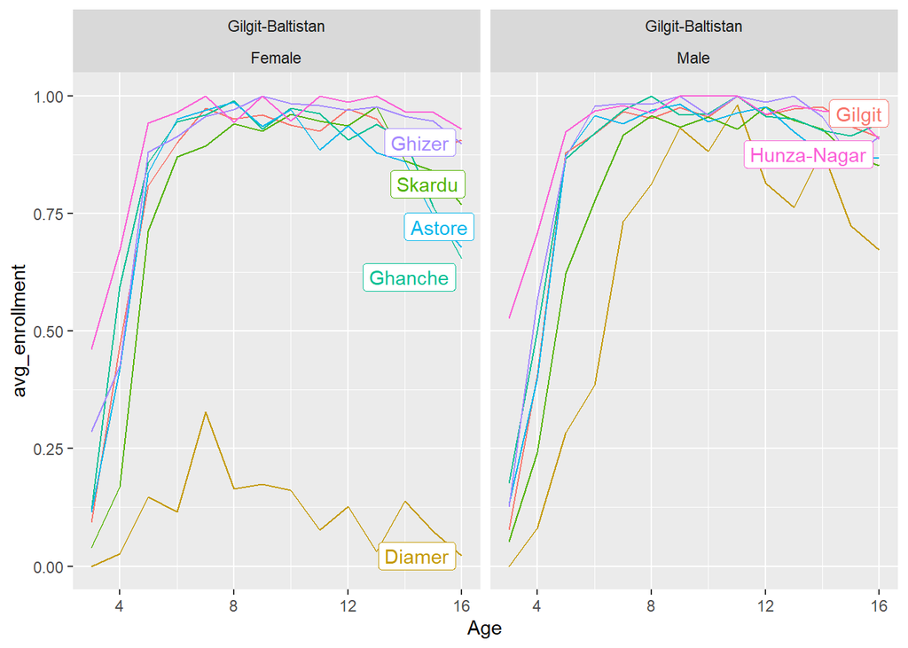

```r
child_ica %>%
  filter(C002 != "NA", RID == 6, RID != "NA") %>%
  group_by(DID, C001, C002) %>%
  mutate(avg_enrollment = mean(C003 == 3, na.rm = TRUE)) %>%
  ggplot(aes(C001, avg_enrollment, color = factor(DID), group = DID)) +
  geom_line() +
  labs(x = "Age") +
  facet_grid(RID~C002, labeller = labeller(RID = RegionName, C002 = Gender)) +
  facet_wrap(RID~C002, labeller = labeller(RID = RegionName, C002 = Gender)) +
  gghighlight(label_key = DNAME, calculate_per_facet = TRUE)
```

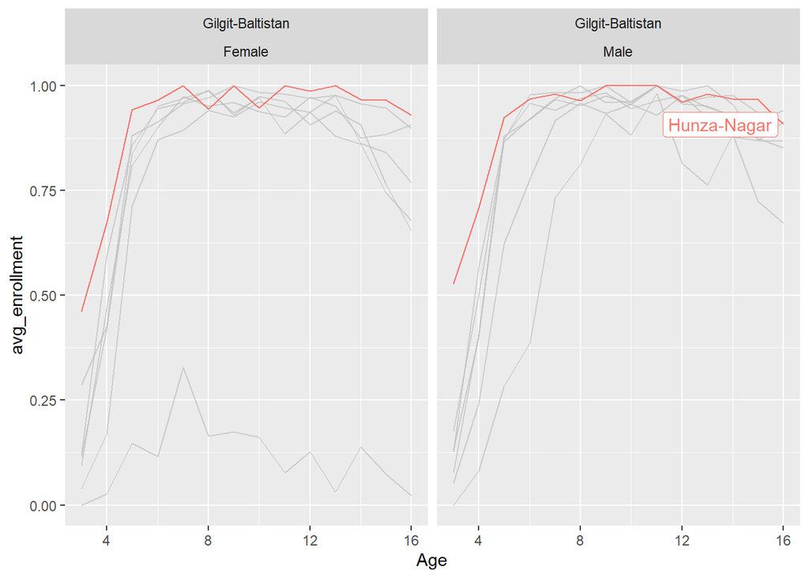

```r
child_ica %>%
  filter(C002 != "NA", RID == 6, RID != "NA") %>%
  group_by(DID, C001, C002) %>%
  mutate(avg_enrollment = mean(C003 == 3, na.rm = TRUE)) %>%
  ggplot(aes(C001, avg_enrollment, color = factor(DID), group = DID)) +
  geom_line() +
  labs(x = "Age") +
  facet_grid(RID~C002, labeller = labeller(RID = RegionName, C002 = Gender)) +
  facet_wrap(RID~C002, labeller = labeller(RID = RegionName, C002 = Gender)) +
  gghighlight(DID == 266,label_key = DNAME, calculate_per_facet = TRUE)
```

#### Karachi

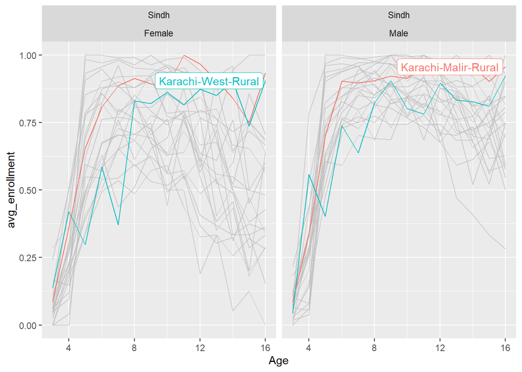

```r
child_ica %>%
  filter(C002 != "NA", RID == 3) %>%
  group_by(DID, C001, C002) %>%
  mutate(avg_enrollment = mean(C003 == 3, na.rm = TRUE)) %>%
  ggplot(aes(C001, avg_enrollment, color = factor(DID), group = DID)) +
  geom_line() +
  labs(x = "Age") +
  facet_grid(RID~C002, labeller = labeller(RID = RegionName, C002 = Gender)) +
  facet_wrap(RID~C002, labeller = labeller(RID = RegionName, C002 = Gender)) +
  gghighlight(DID == c(315,316), label_key = DNAME, calculate_per_facet = TRUE)
```